# Lab 08: Grammar of Graphics

This is our first “lab” of the semester. Each will be structured similarly, with questions interwoven with code snippets. Note that they are numbered to align with the class number. You should put the completed lab in your GitHub repository ahead of the next class meeting.

## Miles Per Gallon

Make sure to start by running the setup chunk above to load the required packages. Then, read in the mpg dataset. There is one row for each particular type of car, with information about the fuel efficiency and other metadata.

```r
mpg <- read_csv("https://statsmaths.github.io/stat_data/mpg.csv")
```

The variable `displ` gives the size of the engine in litres and `cty` the reported miles per gallon of the car while driving in stop-and-go city traffic. Likewise, `hwy` is the miles per gallon for a car on the highway.

Start by making a scatter plot (i.e., points) of engine size on the x-axis and the highway fuel efficiency on the y-axis. (In case this wasn’t clear, write the code in the block below and verify that the plot looks as expected)

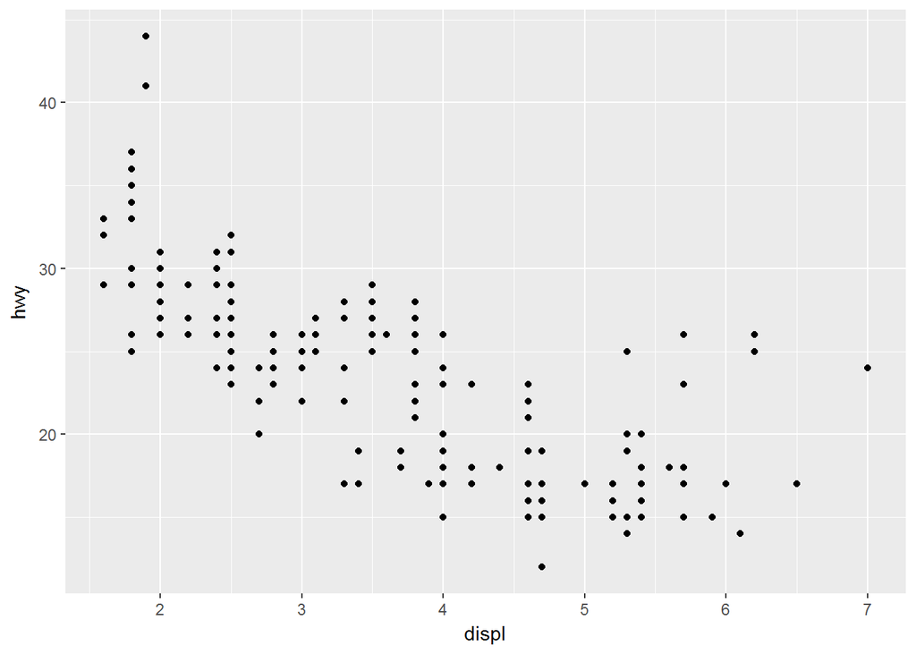

```r
ggplot(mpg, aes(displ, hwy)) +
  geom_point()
```

Verify that the pattern in this plot makes sense.

Next, modify the plot so that the color of the points show the class of the vehicle.

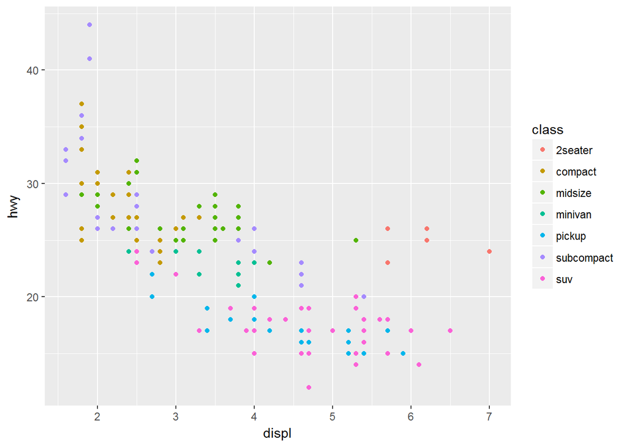

```r
ggplot(mpg, aes(displ, hwy)) +
  geom_point(aes(color = class))
```

Identify a few different classes of vehicles and verify that they appear where you would expect on the plot.

Now, make all of the points in the plot twice as big and color them the color green.

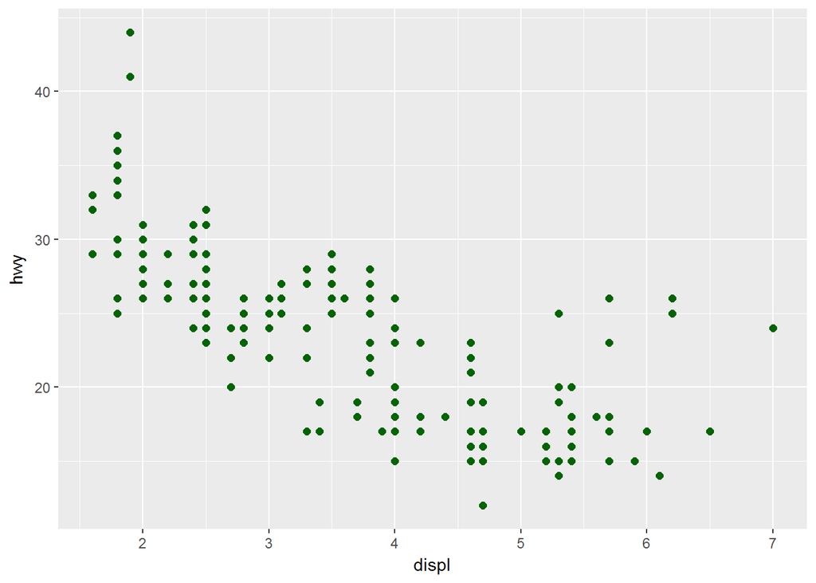

```r
ggplot(mpg, aes(displ, hwy)) +
  geom_point(color = "dark green", size = 2)
```

Next, create two scatter plots at once by adding together `geom_point` layers where one layer uses `hwy` as the y-axis and the other users `cty` as the y-axis (yes, you can override the y aesthetic just like any other).

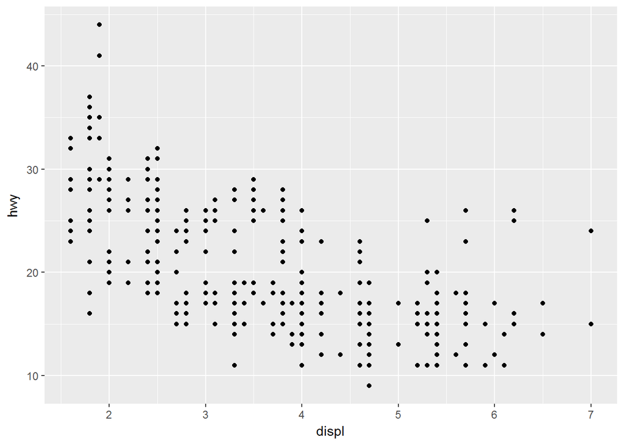

```r
ggplot(mpg, aes(displ, hwy)) +
  geom_point( aes(y = cty)) +
  geom_point()
```

In the previous plot, it is impossible to distinguish between the points that are of the highway fuel efficiencies values and the city fuel efficiencies. Change this by making the city fuel efficiencies colored in red.

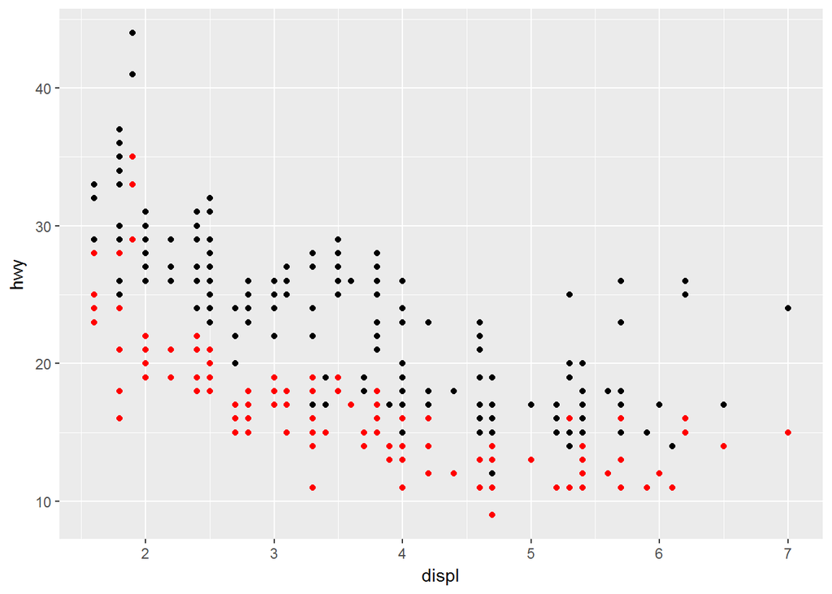

```r
ggplot(mpg, aes(displ, hwy)) +
  geom_point( aes(y = cty), color = "red") +
  geom_point()
```

The default y-axis label is no longer correct because it actually measures two different fuel efficiencies. Add the layer `ylab("Miles Per Gallon")` to the plot to fix this:

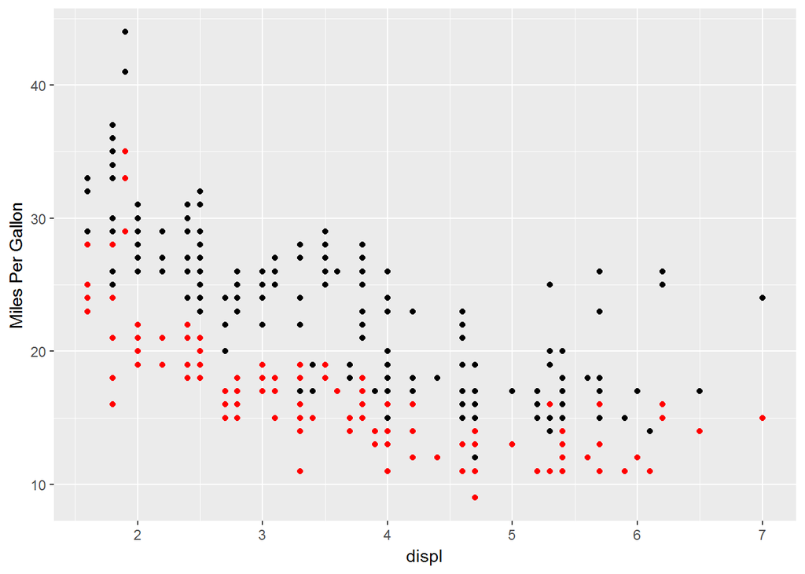

```r
ggplot(mpg, aes(displ, hwy)) +
  geom_point( aes(y = cty), color = "red") +
  geom_point() +
  ylab("Miles Per Gallon")
```

Finally, do the same with the `xlab` and `ggtitle` functions to add a better x-axis and title.

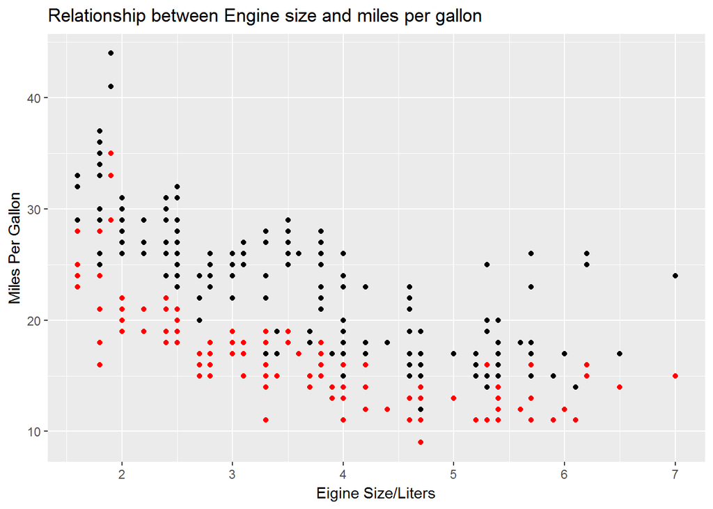

```r
ggplot(mpg, aes(displ, hwy)) +
  geom_point( aes(y = cty), color = "red") +
  geom_point() +
  ylab("Miles Per Gallon") +
  xlab("Eigine Size/Liters") +
  ggtitle("Relationship between Engine size and miles per gallon")
```

## Democratic Primary 2016

Now, load data from the 2016 Democratic Primary elections. The data is given at the county level (this is the **unit of analysis**).

```r
primary <- read_csv("https://statsmaths.github.io/stat_data/primary2016.csv")
```

Start by drawing a scatter plot of latitude and longitude (it is up to you to determine which goes on the x and y axes):

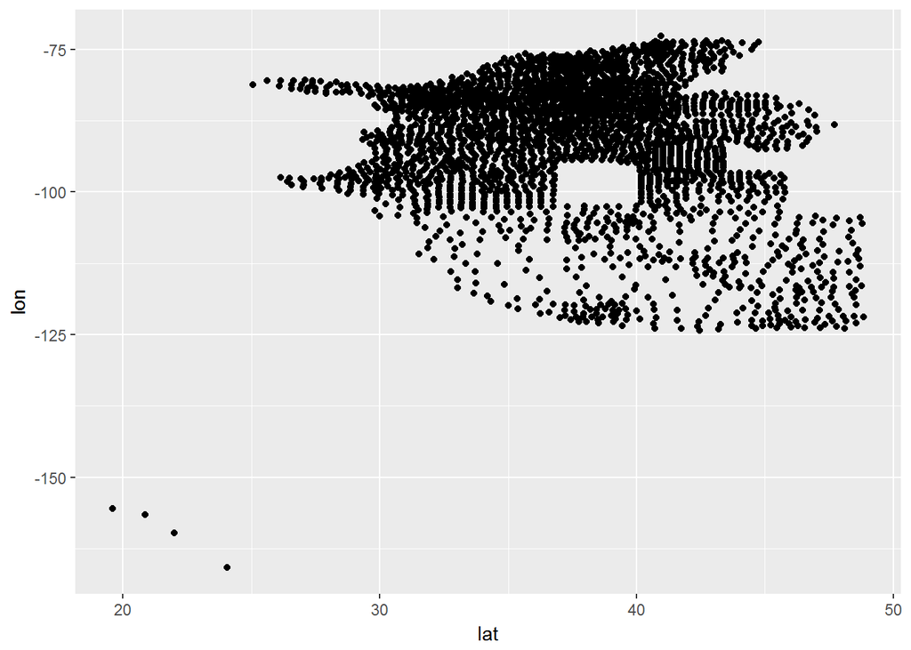

```r
ggplot(primary, aes(lat, lon)) +
  geom_point()
```

Next, color the points based on the variable `division`.

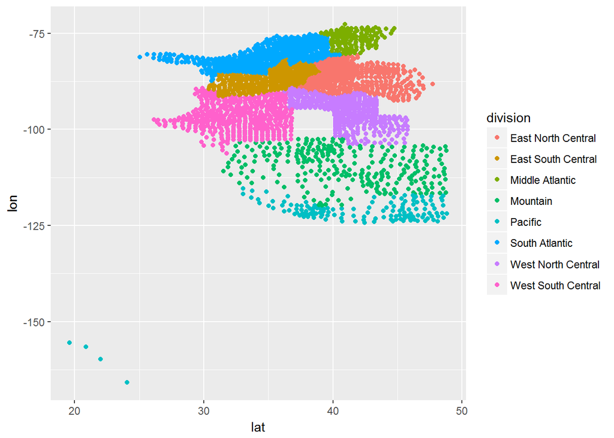

```r
ggplot(primary, aes(lat, lon)) +
  geom_point( aes(color = division))
```

Then, color the points based on the variable `prop_hillary` (the proportion of votes Hillary Clinton received).

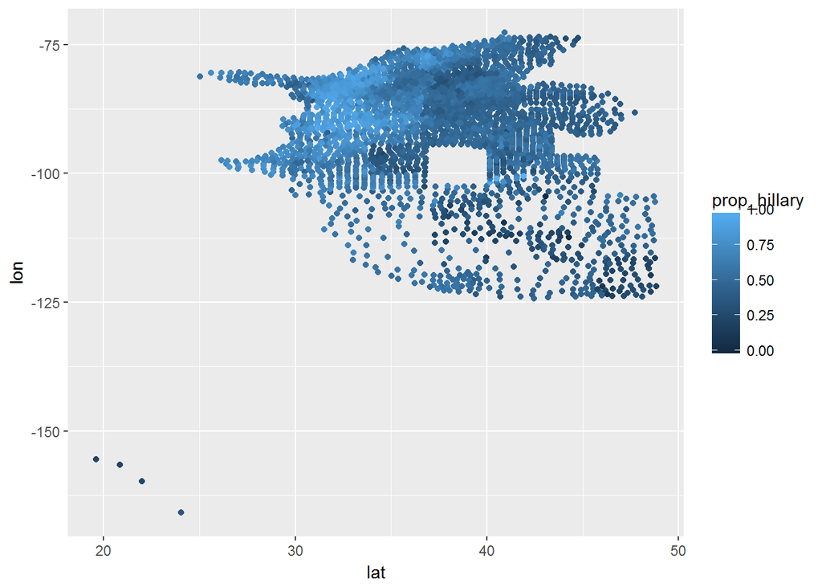

```r
ggplot(primary, aes(lat, lon)) +
  geom_point(aes(color = prop_hillary))
```

Notice any interesting patterns here? Try loading the **viridis** package:

```r
library(viridis)
```

And add `scale_color_viridis()` to the plot:

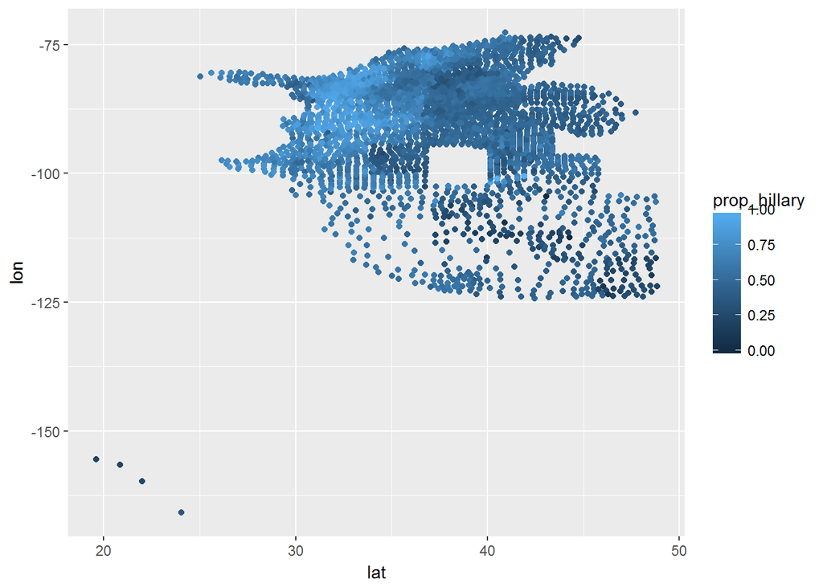

```r
ggplot(primary, aes(lat, lon)) +
  geom_point(aes(color = prop_hillary))
```

```r
  scale_color_viridis()
```

```
## <ScaleContinuous>
##  Range:
##  Limits:    0 --    1
```

It should look much more readable. Do you notice any patterns now?